# Assignment4_VIS

Megan Willis-Jackson

10/7/2020

# Data and Library Loading and Setup

```r
library(osmdata)
library(opentripplanner)
library(tidyverse)
library(sf)
library(ggthemes)
library(ggspatial)
library(raster)
library(units)
library(sp)
library(stringr)
library(rgeos)
library(tidygeocoder)
```

```r
NOLA_performance <- st_read(
  "https://data.nola.gov/api/geospatial/d7bz-pa33?method=export&format=KML",
  quiet = T)

nola_neighborhoods<- st_read("https://opendata.arcgis.com/datasets/e7daa4c977d14e1b9e2fa4d7aff81e59_0.kml?outSR=%7B%22latestWkid%22%3A3452%2C%22wkid%22%3A102682%7D", quiet = T)

nola_french<- st_read("https://opendata.arcgis.com/datasets/e7daa4c977d14e1b9e2fa4d7aff81e59_0.kml?where=OBJECTID%20%3E%3D%201077%20AND%20OBJECTID%20%3C%3D%201077&geometry=%7B%22xmin%22%3A-90.247%2C%22ymin%22%3A29.909%2C%22xmax%22%3A-89.813%2C%22ymax%22%3A30.013%2C%22type%22%3A%22extent%22%2C%22spatialReference%22%3A%7B%22wkid%22%3A4326%7D%7D&outSR=%7B%22latestWkid%22%3A3452%2C%22wkid%22%3A102682%7D", quiet = T)

opq(bbox = 'New Orleans LA USA') %>%
  add_osm_feature(key = 'highway') %>%
  osmdata_xml(file = 'OTP/graphs/default/NOLA_streets.osm')

opq(bbox = 'New Orleans LA USA') %>%
  add_osm_feature(key = 'leisure', value = 'park') %>%
  osmdata_xml(file = 'OTP/graphs/default/NOLA_greenspace.osm')

LA_state_plane <- "+proj=lcc +lat_1=30.7 +lat_2=29.3 +lat_0=28.5 +lon_0=-91.33333333333333 +x_0=1000000 +y_0=0 +ellps=GRS80 +towgs84=0,0,0,0,0,0,0 +units=m +no_defs"
```

```r
nola_street_features <- opq(bbox = 'New Orleans LA USA') %>%
  add_osm_feature(key = 'highway') %>%
  osmdata_sf()

nola_green_features <- opq(bbox = 'New Orleans LA USA') %>%
  add_osm_feature(key = 'leisure', value = 'park') %>%
  osmdata_sf()

nola_streets <- nola_street_features$osm_lines %>%
  st_transform(crs = LA_state_plane)

nola_green <- nola_green_features$osm_polygons
```

```r
path_data <- file.path(getwd(), "OTP")
path_otp <- paste(path_data, "otp.jar",sep = "/")

otp_build_graph(otp = path_otp, dir = path_data, memory = 1024)

otp_setup(otp = path_otp, dir = path_data, memory =1024)

otpcon <- otp_connect()
```

# Isochrones

## Create Isochrones

```r
nola_french_performance<- NOLA_performance[nola_french,]

iso_nola_french <- otp_isochrone(otpcon = otpcon, fromPlace = nola_french_performance,
                                 mode = "CAR", cutoffSec = 600) %>%
  st_transform(crs = LA_state_plane) %>%
  mutate(mode = "drive")

iso_5min_walk <-
  otp_isochrone(otpcon = otpcon, fromPlace = NOLA_performance,
                mode = "WALK", cutoffSec = 300) %>%
  st_transform(crs = LA_state_plane) %>%
  mutate(mode = "walk")

iso_5min_bike <-
  otp_isochrone(otpcon = otpcon, fromPlace = NOLA_performance,
                mode = "BICYCLE", cutoffSec = 300) %>%
  st_transform(crs = LA_state_plane) %>%
  mutate(mode = "bike")

iso_all_modes <- rbind(iso_5min_bike, iso_5min_walk)

otp_stop()
```

```
## [1] "SUCCESS: The process \"java.exe\" with PID 26748 has been terminated."
```

## Map Isochrones

The map below shows the isochrones for 5 minutes of walking and biking from each of the performance venues located in downtown New Orleans. Downtown New Orleans is here defined as any area of NOLA reachable within 10 minutes by car from the French Quarter, which may not align with the technical definition.

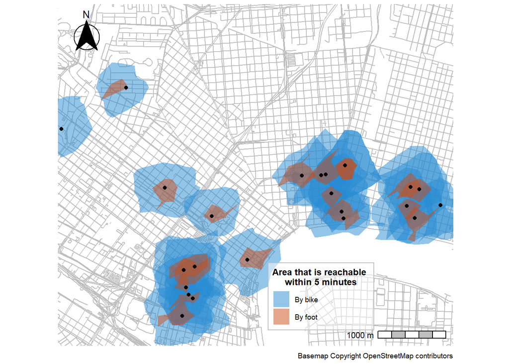

```r
right_side <- st_bbox(iso_nola_french)$xmax+1000
left_side  <- st_bbox(iso_nola_french)$xmin+2000
top_side <- st_bbox(iso_nola_french)$ymax-1000
bottom_side <- st_bbox(iso_nola_french)$ymin+500

ggplot(iso_all_modes) +
  geom_sf(data = nola_streets, color = "grey") +
  geom_sf(aes(fill = mode), color = NA, alpha = 0.5) +
  geom_sf(data = NOLA_performance) +
  coord_sf(xlim = c(left_side, right_side),
           ylim = c(bottom_side, top_side), expand = FALSE) +
  scale_fill_solarized(name = "Area that is reachable \nwithin 5 minutes",
                       labels = c("By bike", "By foot")) +
  annotation_north_arrow(location = "tl",
                         style = north_arrow_fancy_orienteering(line_col = "black",fill = "black")) +
  annotation_scale(location = "br", bar_cols = c("white","grey")) +
  theme_map() +
  theme(legend.background = element_rect(fill = alpha("white",.5), color = "grey"),
        legend.justification = c(-1.99,-.23),
        legend.title = element_text(face = "bold"),
        legend.title.align = .5) +
  labs(caption = "Basemap Copyright OpenStreetMap contributors")
```

## Isochrone Scatterplot

The scatter plot below shows the area accessible by biking versus by walking from the same performance venue. This chart is decently linear, but some deviations from what would be a perfect line indicate that there are venues in places not easily accessible by bikes and also some that bikes can travel proportionally faster/with more ease than they could on foot.

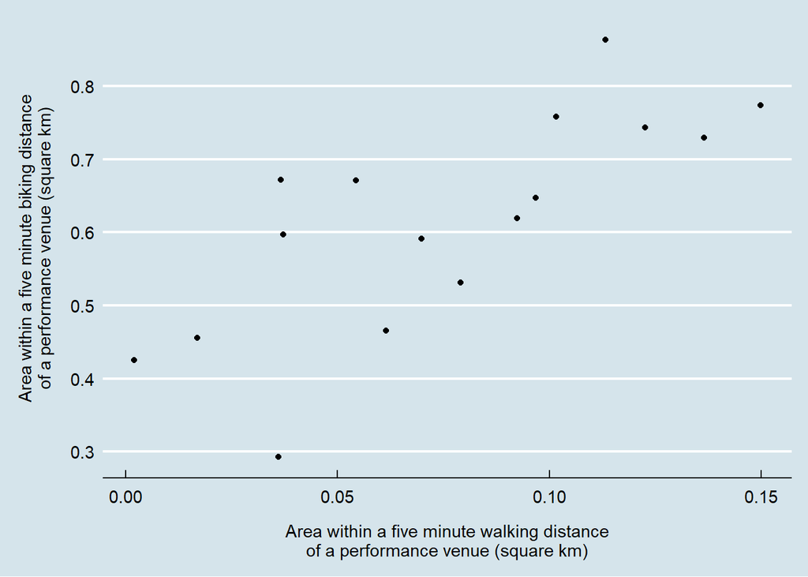

```r
iso_relevant<- iso_all_modes[iso_nola_french,]

iso_relevant<- iso_relevant %>%
  distinct(fromPlace, .keep_all = T)

iso_areas<- iso_relevant %>%
  mutate(area = set_units(st_area(iso_relevant), km^2)) %>%
  st_set_geometry(NULL) %>%
  pivot_wider(names_from = mode, values_from = area)

ggplot(iso_areas,
       aes(x = as.numeric(walk), y = as.numeric(bike))) +
  geom_point() +
  scale_x_continuous(name =
                       "\nArea within a five minute walking distance\nof a performance venue (square km)") +
  scale_y_continuous(name = "Area within a five minute biking distance\nof a performance venue (square km)\n") +
  theme_economist()
```

## Isochrone Total Areas

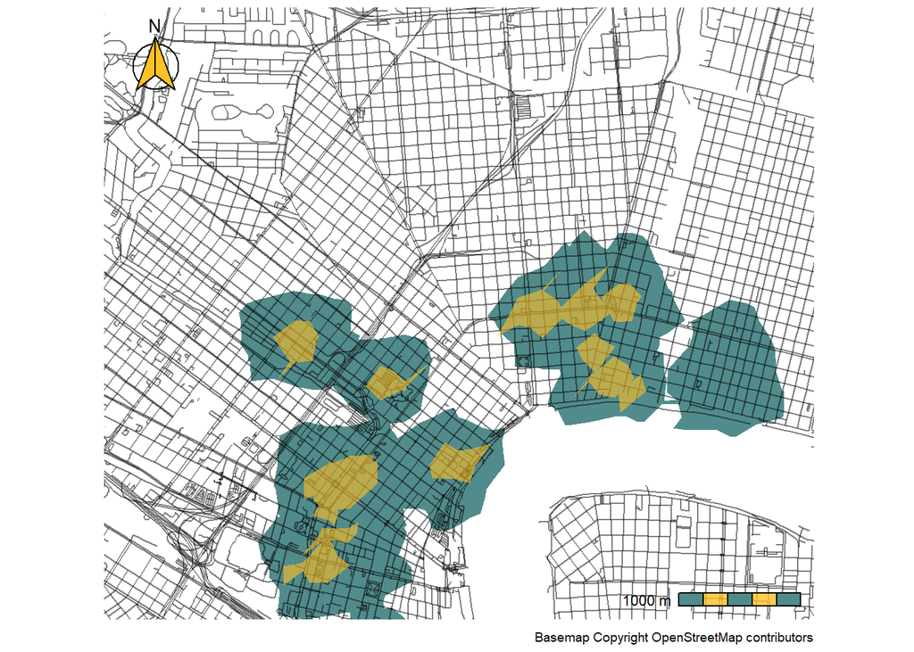

```r
total_area_bike<- st_as_sf(st_union(iso_5min_bike$geometry[iso_nola_french,]))

total_area_walk<- st_as_sf(st_union(iso_5min_walk$geometry[iso_nola_french,]))

ggplot(nola_streets) +
  geom_sf(data = total_area_bike, fill = "darkslategray4", color = NA) +
  geom_sf(color = "black", alpha = .5) +
  geom_sf(data = total_area_walk, fill = "goldenrod1", alpha = .6, color = NA) +
  theme_map() +
  coord_sf(xlim = c(left_side, right_side),
           ylim = c(bottom_side, top_side), expand = FALSE) +
  annotation_north_arrow(location = "tl",
                         style = north_arrow_fancy_orienteering(line_col = "black",fill = "goldenrod1")) +
  annotation_scale(location = "br", bar_cols = c("darkslategray4", alpha("goldenrod1", .8))) +
  theme(legend.background = element_rect(fill = alpha("white",.5), color = "grey"),
        legend.justification = c(-1.99,-.23),
        legend.title = element_text(face = "bold"),
        legend.title.align = .5,
        legend.position = "right") +
  labs(caption = "Basemap Copyright OpenStreetMap contributors")
```

The below bar chart shows the total distance accessible by 5 minutes of biking and 5 minutes of walking from all of the performance venues in downtown New Orleans. As expected, one can reach a much larger area by bike than by foot leaving any of the performance venues.

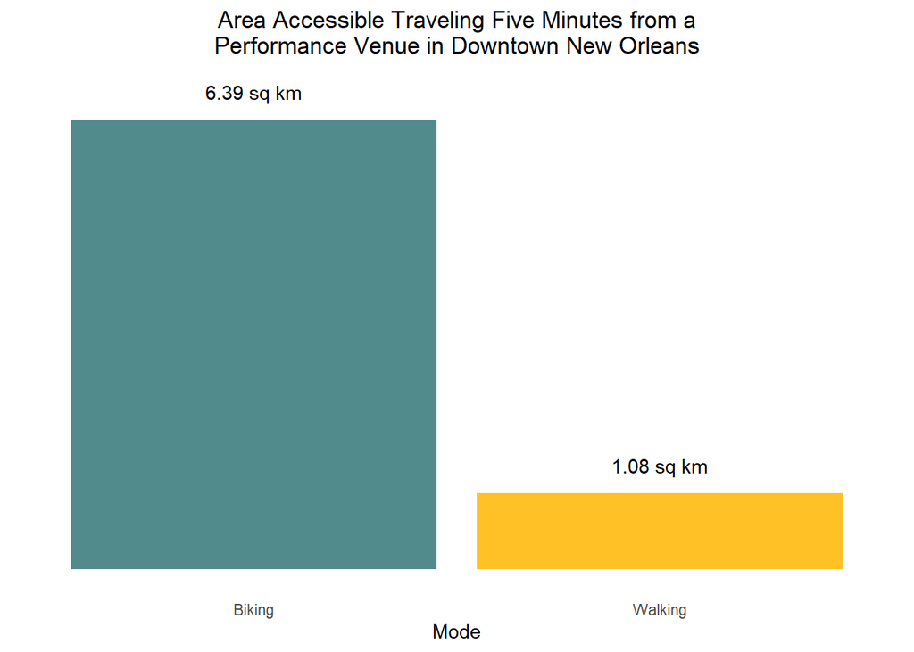

```r
total_area_bike_sum<- set_units(st_area(total_area_bike), km^2)

total_area_walk_sum<- set_units(st_area(total_area_walk), km^2)

mode_temp<- c("walk area", "bike area")
area_temp<- c(total_area_walk_sum, total_area_bike_sum)
total_area<- data.frame(mode_temp, as.numeric(substr(area_temp,1,8)))
colnames(total_area)<- c("mode", "area")

ggplot(total_area,
       aes(x = mode,
           y = area)) +
  geom_col(fill = c("goldenrod1", "darkslategray4")) +
  scale_y_continuous(name = NULL,
                     labels = NULL,
                     breaks = NULL) +
  scale_x_discrete(name = "Mode",
                   labels = c("Biking","Walking")) +
  geom_text(label = paste(prettyNum(total_area$area, digits = 3),"sq km"),
            nudge_y = .4) +
  #scale_fill_discrete(aes(fill = c("darkslategray4","goldenrod1"))) +
  labs(title = "Area Accessible Traveling Five Minutes from a\nPerformance Venue in Downtown New Orleans") +
  theme(legend.position = "none",
        panel.background = element_rect(fill = "white"),
        plot.title = element_text(hjust = .5),
        axis.ticks.x = element_blank())
```